# Intro to R for Policy Analysis

2024-02-27

## Goals for today

- Learn basic operating features of R & R markdown
- Types of data types and frames
- Basic object oriented programming
- Application to mapping police violence

## Key things about R

- Can read & process most data types
  - .txt, .csv, .xlsx files, etc.
- A VERY large calculator
- Object based oriented
- naming is VERY important
  - Case sensitive

```r
g = 6 * 6 + 8
g
```

```
## [1] 44
```

## On sequences

- R all about SEQUENCE of code
  - Must be run in order
  - Failure = “object does no exist” error
- Various special commands to do more than math;
  - Usually where things break down
  - i.e., wrong package
- create objects with = or <-

```r
try(y+8)
```

```
## Error in try(y + 8) : object 'y' not found
```

## Correct sequence: Rise over run

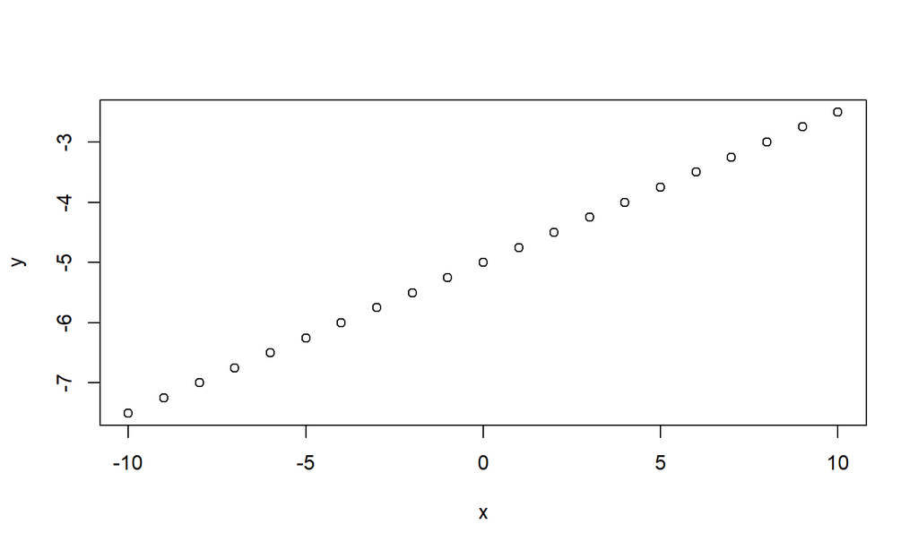

```r
m = 0.25
x = seq(-10,10,by=1) ## note, this is one of those special commands
b = -5 # IF you couldn't guess, the hashtag comments out code
y = m*x + b
plot(x,y) ## here is another, a function that takes x then y
```

## Implications?

- Most common errors b/c lines not run in correct sequence
  - i.e., highlight all code, then click “run” button
- “Dependencies” critical to understanding programming
- Don’t despair at errors;
  - Deep breath, then debug
  - Google is your friend
    - Google the message in the error
  - note: Never spend more than 30 minutes alone debugging by self

## On functions

- Some cool things not in base R
- Can create “functions” to do cool things given inputs
  - i.e, the same math applied over and over again
- Functions are likewise objects
- Use the core “function” followed by parameters in parentheses

```r
cool_fxn <- function(x,slope,intercept){
  y = x*slope + intercept
  return(y)
}

cool_fxn(x=seq(0,10,by=1), slope=0.4,intercept=2)
```

```
##  [1] 2.0 2.4 2.8 3.2 3.6 4.0 4.4 4.8 5.2 5.6 6.0
```

## Libraries

- Some functions grouped together in “packages”
  - Can be downloaded for free
    - cough, Hobbes is wrong, cough
- Just use the “library” command
  - Will have access to a bunch of new functions
- Want them at start of script

```r
library(stringr) # use command "library" to load in a set of functions
x = "Hedgehogs are cool"
y = str_replace(x, "are", "R") # this fxn from the stringr package
y
```

```
## [1] "Hedgehogs R cool"
```

## Reading in data

- R is awesome because it processes data
  - Stuff in excel files, for example
- Folder directory structure EXTREMELY important
- File path how R identifies files

```r
list.files("images",full.names = TRUE) # list files gets you all of
```

```
## [1] "images/capy_love_all.png"    "images/corgi_journalist.png"
## [3] "images/corgi_wardrobe.jpg"   "images/dexter.jpg"
## [5] "images/folders.png"          "images/geese.jpg"
```

```r
# the files in a folder, which is in quotes
```

## Example folder structure

[figure not shown]

```r
knitr::include_graphics("images/folders.png") # note: R is able to read this
```

```r
# b/c the Rmd file is saved immediately above the "images" folder
```

## Class types

- Basic class types: vector, matrix, data frame, list
  - Vector: sequence of things
  - matrix: bunch of vectors in rectangular format
  - data frame: a matrix with labels, i.e., column names
  - list: whatever you want to shove into it

```r
rrr = seq(1,100,by=5)
is.vector(rrr)
```

```
## [1] TRUE
```

## Example of matrix

```r
N = 100
M = 20
set.seed(1337) ## making replicable
test_matrix <- matrix( rnorm(N*M,mean=0,sd=1), N, M)  ### new command!!!
class(test_matrix)
```

```
## [1] "matrix" "array"
```

```r
is.matrix(test_matrix)
```

```
## [1] TRUE
```

```r
test_matrix
```

```
##               [,1]         [,2]         [,3]         [,4]        [,5]
##   [1,]  0.19249191  0.209976795  1.162209809  0.714741783  0.09657901
##   [2,] -1.44670181 -0.385029307  0.356993279 -0.540005913 -0.40916458
##   [3,] -0.32318053  1.371785071 -0.942337112 -0.836144422 -0.60769922
##   [4,]  1.62229612  0.158983203 -1.152568608  1.898093945 -1.04518285
##   [5,] -0.68902412 -0.204857054 -0.383855489  0.079432651  0.50442940
##   [6,]  2.04212222 -0.852092160  0.010314308 -1.344425624 -1.00560422
##   [7,]  0.94377911 -0.809472181 -1.045938661  1.613704729  1.70187526
##   [8,]  2.08192688  0.533398962 -0.702270397  0.673798437 -0.13669543
##   [9,]  1.91711728  0.068738467 -0.297296211  1.425315843 -0.10148834
##  [10,] -0.41481224 -0.736781481  0.642910358 -0.354730651  1.82767723
##  [11,]  1.03285350 -0.469162098 -1.011574291 -0.400504087  0.81754032
##  [12,] -1.67856959 -0.674665999 -1.023753807 -0.157517371  1.57790416
##  [13,]  0.15754969 -0.739777828 -0.782264488 -0.327964925 -0.65222324
##  [14,]  1.48913612  1.197226967 -2.689387176 -1.030759902 -1.49956893
```

[output cut: 389 more lines]

## Example of list

```r
messy_list = list(rrr,test_matrix) # since we ran these before,
# these are real objects that can be shoved into a list
messy_list[[1]]
```

```
##  [1]  1  6 11 16 21 26 31 36 41 46 51 56 61 66 71 76 81 86 91 96
```

```r
messy_list[[2]]
```

```
##               [,1]         [,2]         [,3]         [,4]        [,5]
##   [1,]  0.19249191  0.209976795  1.162209809  0.714741783  0.09657901
##   [2,] -1.44670181 -0.385029307  0.356993279 -0.540005913 -0.40916458
##   [3,] -0.32318053  1.371785071 -0.942337112 -0.836144422 -0.60769922
##   [4,]  1.62229612  0.158983203 -1.152568608  1.898093945 -1.04518285
##   [5,] -0.68902412 -0.204857054 -0.383855489  0.079432651  0.50442940
##   [6,]  2.04212222 -0.852092160  0.010314308 -1.344425624 -1.00560422
##   [7,]  0.94377911 -0.809472181 -1.045938661  1.613704729  1.70187526
##   [8,]  2.08192688  0.533398962 -0.702270397  0.673798437 -0.13669543
##   [9,]  1.91711728  0.068738467 -0.297296211  1.425315843 -0.10148834
##  [10,] -0.41481224 -0.736781481  0.642910358 -0.354730651  1.82767723
##  [11,]  1.03285350 -0.469162098 -1.011574291 -0.400504087  0.81754032
##  [12,] -1.67856959 -0.674665999 -1.023753807 -0.157517371  1.57790416
##  [13,]  0.15754969 -0.739777828 -0.782264488 -0.327964925 -0.65222324
##  [14,]  1.48913612  1.197226967 -2.689387176 -1.030759902 -1.49956893
```

[output cut: 389 more lines]

## Reading in files & data frames

- Need to know file type
- Goal: read in “data frames”
  - Matrix like objects
- Need ’foreign”, “haven”, and “readxl” libraries

```r
## reading in from data folder
mpv_df = read.csv("data/mpv_df02232024.csv") # note,
# .csv are essentially format restricted excel files
class(mpv_df)
```

```
## [1] "data.frame"
```

```r
names(mpv_df) # "names" get the name of every column
```

```
##  [1] "ï..name"                           "age"
##  [3] "gender"                            "race"
##  [5] "victim_image"                      "date"
##  [7] "street_address"                    "city"
##  [9] "state"                             "zip"
## [11] "county"                            "agency_responsible"
## [13] "ori"                               "cause_of_death"
## [15] "circumstances"                     "disposition_official"
## [17] "officer_charged"                   "news_urls"
## [19] "signs_of_mental_illness"           "allegedly_armed"
## [21] "wapo_armed"                        "wapo_threat_level"
## [23] "wapo_flee"                         "wapo_body_camera"
## [25] "wapo_id"                           "off_duty_killing"
## [27] "geography"                         "mpv_id"
## [29] "fe_id"                             "encounter_type"
```

[output cut: 16 more lines]

## Using data frames

- Always want to inspect
  - Size, types, missingness, etc.
- What you’ll use for most data analysis
- Figure out descriptive stats first
- Create plan on how to visualize; forecast

```r
dim(mpv_df) # gets rows by columns
```

```
## [1] 12724    62
```

```r
str(mpv_df[,1]) # brackets get the row by cols; find data types
```

```
##  chr [1:12724] "Name Withheld" "Donald Friese" "Javaria R. Taylor" ...
```

```r
# summary(mpv_df[,2])
```

## Data types

- Lots of “data types” can be shoved in DFs
  - Numeric: (11.6, 10, 555.345)
  - Integer: numeric, but no decimals
  - Complex - numeric w/imaginary numbers
  - Character - text data
  - Logical: TRUE or FALSE, aka Boolean

## Data types, example

```r
str(mpv_df) # the "str" command tells you data types;
```

```
## 'data.frame':    12724 obs. of  62 variables:
##  $ ï..name                          : chr  "Name Withheld" "Donald Friese" "Javaria R. Taylor" "Name Withheld" ...
##  $ age                              : int  NA 39 19 NA 38 65 36 43 17 46 ...
##  $ gender                           : chr  "Male" "Male" "Male" "Male" ...
##  $ race                             : chr  "Unknown race" "White" "Black" "Unknown race" ...
##  $ victim_image                     : chr  "" "https://bloximages.newyork1.vip.townnews.com/stltoday.com/content/tncms/assets/v3/editorial/8/65/865350fa-3287-"| __truncated__ "" "" ...
##  $ date                             : chr  "2/8/2024" "2/7/2024" "2/7/2024" "2/7/2024" ...
##  $ street_address                   : chr  "Sixth St & Hamner Ave" "Illinois Route 146" "8200 Pines Rd" "14600 block of Lourdes Drive" ...
##  $ city                             : chr  "Norco" "East Cape Girardeau" "Shreveport" "Houston" ...
##  $ state                            : chr  "CA" "IL" "LA" "TX" ...
##  $ zip                              : chr  "92860" "62957" "71129" " 77049" ...
##  $ county                           : chr  "Lynn" "Alexander" "Caddo" "Harris" ...
##  $ agency_responsible               : chr  "Riverside County Sheriff's Office " "Cape Girardeau Police Department,East Cape Girardeau Police Department" "Caddo Parish Sheriff's Office,Bossier City Police Department,Bossier Parish Sheriff's Office" "Harris County Sheriff's Office,U.S. Marshal Serv…
##  $ ori                              : chr  "" "" "" "" ...
##  $ cause_of_death                   : chr  "Gunshot" "Gunshot" "Gunshot" "Gunshot" ...
```

[output cut: 48 more lines]

```r
# might also be
```

## Getting summary stats

- Use the “summary” fxn
  - Gets min, max, ave, med, etc.
- Look at “quantiles” as you set them
  - Always a fun first cut
- Use the “$” to pull a column from df to treat as vector

```r
summary(mpv_df$pop_total_census_tract) # the go to fxn for summaries
```

```
##    Min. 1st Qu.  Median    Mean 3rd Qu.    Max.    NA's
##       0    3147    4352    4658    5719   61133      62
```

```r
quantile(mpv_df$pop_total_census_tract,seq(0,1,by=0.1),na.rm=T) # use sequence to dist
```

```
##      0%     10%     20%     30%     40%     50%     60%     70%     80%     90%
##     0.0  2282.1  2885.0  3411.3  3903.0  4352.0  4839.0  5401.0  6092.0  7191.0
##    100%
## 61133.0
```

```r
# na.rm=T removes missing data that would otherwise break
```

## Creating simplified tables

- Want to simplify data read in
  - Descriptive purpose
- Best to use “tidyverse” pkg
  - Piping to do sequential commands

```r
library(tidyverse) # for piping and such
library(knitr) # gets cool tables in R markdown
simp_tbl <- mpv_df %>% ## calls df
  group_by(race) %>% ## this pipes and groups by
  tally() # gets a tally of above
```

## Results

```r
kable(simp_tbl) # command from knitr; full tbl not visible
```

| race | n |
| --- | --- |
|  | 223 |
| Asian | 177 |
| Black | 3180 |
| Hispanic | 2206 |
| Native American | 161 |
| Native Hawaiian and Pacific Islander | 74 |
| Unknown race | 1241 |
| White | 5462 |

## Graphics and descriptive stats

- Want to get at distribution
  - Presented in easy to understand way
- Key features:
  - Central tendancy: mean, median, mode
  - Variance: Deviation from centrality
  - Skewness: Asymmetry from distribution
  - Kurtosis: Peaks/flats along distribution
- Present these to identify “problems” in data generating process (DGP)

## Analyzing police violence by agency

```r
num_agencies <- mpv_df %>% # creating a new object, called "num_agencies"
  group_by(agency_responsible,state) %>% # pipe tells to summarize by these
  tally() # tally gets the number of by groups above
## get size of df
dim(num_agencies) # 3 cols: agency_responsible, state, and n
```

```
## [1] 4704    3
```

```r
# 4704 rows
### get the dist of deaths in data by agency
quantile(num_agencies$n, seq(0,1,0.05)) #95th pct at 8; very skewed data
```

```
##   0%   5%  10%  15%  20%  25%  30%  35%  40%  45%  50%  55%  60%  65%  70%  75%
##    1    1    1    1    1    1    1    1    1    1    1    1    1    1    2    2
##  80%  85%  90%  95% 100%
##    2    3    4    8  184
```

```r
##look at above 95th pct
quantile(num_agencies$n, seq(0.95,1,0.01)) # top 1 pct
```

```
##  95%  96%  97%  98%  99% 100%
##    8   10   13   17   28  184
```

```r
# above 28; let's subset
top1percent <- subset(num_agencies, n > 28)
sum(top1percent$n)/nrow(mpv_df) ## tells us top 1% of depts responsible for
```

```
## [1] 0.2096825
```

```r
# 20 percent of deaths
nrow(top1percent)
```

```
## [1] 46
```

## What we learned?

- 4704 agencies responsible for lethal police violence
- Most agencies in data killed one over decade +
- Relatively few (46 of 4704) responsible for 20% of deaths
- Who are these agencies?
  - Time to plot
- Tool: GGplot
  - commands: ggplot(), geom_density, and geom_text
  - arguments: data; aes (aesthetics), x, y, fill, and color
- Goal: identify main outliers and distribution
  - Create code to see norm in field of policy analysis

## Plotting

```r
# create a position variable for scattering
num_agencies$y_pos = 0.3 + runif(nrow(num_agencies), min=0.1,max=1.1)
### create a plot for the num og agencies, distribution
update_geom_defaults("text", list(size = 24))
agency_kill_dist <- ggplot(data=num_agencies, aes(x=n, y=..scaled..,
                                                  fill="Police killings",col="Police killings")) +
  geom_density() +  theme_minimal() + theme(legend.position="none") +
  geom_text(data=subset(num_agencies,n>28), aes(y=y_pos, x=n,
                                                label=stringr::str_wrap(agency_responsible,30), size=n,
                                                col=as.factor(state)),alpha=0.6) +
  xlim(0,250) + labs(title="Distribution police killings by police department",y="Density",
                     x="Number of killings by police",
                     caption="Text entries are the top 1% of agencies responsible for killings. Weighted as
                     the n of killings. Colors assigned by state of agency.")+
  theme(axis.text=element_text(size=12),
        title=element_text(size=12,face="bold"),legend.text = element_text(size=10)) +
  scale_size(
    breaks = c(10, 50, 100, 150,200,250),
    range = c(2, 6)
  )
ggsave("plots/agency_shooting_dist.jpeg",
       plot=agency_kill_dist, scale=1,width=9,
       height=6,units = c("in"),dpi=600, bg="white")
```

## Presenting results

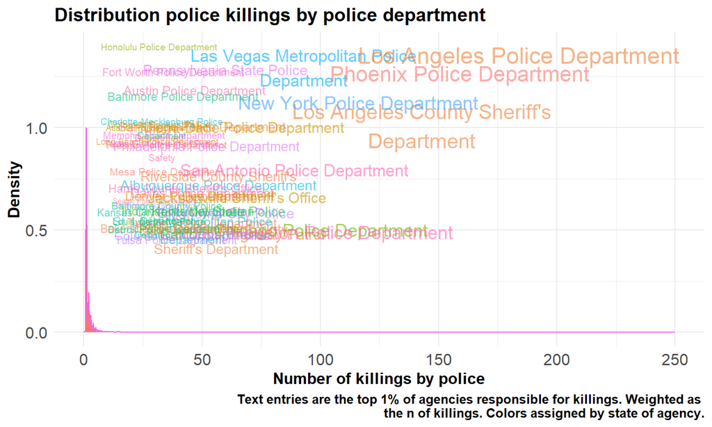

```r
agency_kill_dist
```

## Takeaways

- R is a strong processor of information
  - Normal math
  - External data
- A primary way to summarize data
  - Mean, median, mode, range, etc.
- Crucial for data visualization
- WILL take time to learn
  - i.e., ggplot aspects take experimentation; time
- Necessary for sustainable jobs in policy analysis